# bsscol ReadMe

bsscol allows for a simple integration of the BSS base colors into ggplot2 and alike.

### installation and loading

You can install the released version of bsscol from [Github](https://github.com/qwertzlbry/bsscol) with:

```r
library(devtools) # install devtool first if not installed
install_github("qwertzlbry/bsscol")
```

Or just copy the package folder from: “$G:\BSS\Administration\05_BSS_Vorlagen\Farben_R_Stata\bsscol$” into your local R library and load it.

With a future CRAN approval the package could be installed with:

```r
install.packages("bsscol") # currently the installation works only over github
```

In order to run the following examples you’ll also need:

```r
install.packages("ggplot2")
install.packages("plotrix")
install.packages("dplyr")
install.packages("hues")
install.packages("ggthemes")
install.packages("DT")
install.packages("kableExtra")
```

```r
library(bsscol)
library(ggplot2)
library(plotrix)
library(hues)
library(ggthemes)
library(dplyr, warn.conflicts=F, quietly=T)
library(kableExtra, warn.conflicts=F, quietly=T)
```

## the colors

### all colors

The following table contains all the BSS colors. When the package is loaded this table can be called with the `bss_colors` command.

| R | G | B | hex | Typ | Full | col_pal | hashed_hex | excel_form | name |
| --- | --- | --- | --- | --- | --- | --- | --- | --- | --- |
| 255 | 255 | 255 | FFFFFF | 0 | 255,255,255 | 1 | #FFFFFF | 1 | weiss |
| 242 | 242 | 242 | F2F2F2 | -5 | 242,242,242 | 1 | #F2F2F2 | 11 | NA |
| 217 | 217 | 217 | D9D9D9 | -15 | 217,217,217 | 1 | #D9D9D9 | 21 | NA |
| 191 | 191 | 191 | BFBFBF | -25 | 191,191,191 | 1 | #BFBFBF | 31 | NA |
| 166 | 166 | 166 | A6A6A6 | -35 | 166,166,166 | 1 | #A6A6A6 | 41 | NA |
| 128 | 128 | 128 | 808080 | -50 | 128,128,128 | 1 | #808080 | 51 | NA |
| 0 | 0 | 0 | 000000 | 0 | 0,0,0 | 2 | #000000 | 2 | schwarz |
| 128 | 128 | 128 | 808080 | 50 | 128,128,128 | 2 | #808080 | 12 | NA |
| 89 | 89 | 89 | 595959 | 35 | 89,89,89 | 2 | #595959 | 22 | NA |
| 64 | 64 | 64 | 404040 | 25 | 64,64,64 | 2 | #404040 | 32 | NA |
| 38 | 38 | 38 | 262626 | 15 | 38,38,38 | 2 | #262626 | 42 | NA |
| 13 | 13 | 13 | 0D0D0D | 5 | 13,13,13 | 2 | #0D0D0D | 52 | NA |
| 242 | 242 | 242 | F2F2F2 | 0 | 242,242,242 | 3 | #F2F2F2 | 3 | hellgrau1 |
| 218 | 218 | 218 | DADADA | -10 | 218,218,218 | 3 | #DADADA | 13 | NA |
| 182 | 182 | 182 | B6B6B6 | -25 | 182,182,182 | 3 | #B6B6B6 | 23 | NA |
| 121 | 121 | 121 | 797979 | -50 | 121,121,121 | 3 | #797979 | 33 | NA |
| 61 | 61 | 61 | 3D3D3D | -75 | 61,61,61 | 3 | #3D3D3D | 43 | NA |
| 23 | 23 | 23 | 171717 | -90 | 23,23,23 | 3 | #171717 | 53 | NA |
| 191 | 191 | 191 | BFBFBF | 0 | 191,191,191 | 4 | #BFBFBF | 4 | grau |
| 242 | 242 | 242 | F2F2F2 | 80 | 242,242,242 | 4 | #F2F2F2 | 14 | NA |
| 230 | 230 | 230 | E6E6E6 | 60 | 230,230,230 | 4 | #E6E6E6 | 24 | NA |
| 217 | 217 | 217 | D9D9D9 | 40 | 217,217,217 | 4 | #D9D9D9 | 34 | NA |
| 143 | 143 | 143 | 8F8F8F | -25 | 143,143,143 | 4 | #8F8F8F | 44 | NA |
| 96 | 96 | 96 | 606060 | -50 | 96,96,96 | 4 | #606060 | 54 | NA |
| 21 | 95 | 144 | 155F90 | 0 | 21,95,144 | 5 | #155F90 | 5 | blau |
| 193 | 225 | 247 | C1E1F7 | 80 | 193,225,247 | 5 | #C1E1F7 | 15 | NA |
| 135 | 197 | 237 | 87C5ED | 60 | 135,197,237 | 5 | #87C5ED | 25 | NA |
| 73 | 167 | 228 | 49A7E4 | 40 | 73,167,228 | 5 | #49A7E4 | 35 | NA |
| 16 | 71 | 107 | 10476B | -25 | 16,71,107 | 5 | #10476B | 45 | NA |
| 11 | 48 | 72 | 0B3048 | -50 | 11,48,72 | 5 | #0B3048 | 55 | NA |
| 171 | 228 | 65 | ABE441 | 0 | 171,228,65 | 6 | #ABE441 | 6 | grün |
| 238 | 250 | 216 | EEFAD8 | 80 | 238,250,216 | 6 | #EEFAD8 | 16 | NA |
| 221 | 244 | 179 | DDF4B3 | 60 | 221,244,179 | 6 | #DDF4B3 | 26 | NA |
| 204 | 238 | 140 | CCEE8C | 40 | 204,238,140 | 6 | #CCEE8C | 36 | NA |
| 134 | 191 | 28 | 86BF1C | -25 | 134,191,28 | 6 | #86BF1C | 46 | NA |
| 90 | 129 | 18 | 5A8112 | -50 | 90,129,18 | 6 | #5A8112 | 56 | NA |
| 229 | 35 | 61 | E5233D | 0 | 229,35,61 | 7 | #E5233D | 7 | rot |
| 250 | 209 | 215 | FAD1D7 | 80 | 250,209,215 | 7 | #FAD1D7 | 17 | NA |
| 244 | 166 | 175 | F4A6AF | 60 | 244,166,175 | 7 | #F4A6AF | 27 | NA |
| 239 | 122 | 137 | EF7A89 | 40 | 239,122,137 | 7 | #EF7A89 | 37 | NA |
| 176 | 21 | 40 | B01528 | -25 | 176,21,40 | 7 | #B01528 | 47 | NA |
| 118 | 14 | 27 | 760E1B | -50 | 118,14,27 | 7 | #760E1B | 57 | NA |
| 238 | 236 | 34 | EEEC22 | 0 | 238,236,34 | 8 | #EEEC22 | 8 | gelb |
| 252 | 252 | 209 | FCFCD1 | 80 | 252,252,209 | 8 | #FCFCD1 | 18 | NA |
| 249 | 249 | 166 | F9F9A6 | 60 | 249,249,166 | 8 | #F9F9A6 | 28 | NA |
| 244 | 244 | 121 | F4F479 | 40 | 244,244,121 | 8 | #F4F479 | 38 | NA |
| 189 | 189 | 15 | BDBD0F | -25 | 189,189,15 | 8 | #BDBD0F | 48 | NA |
| 126 | 126 | 10 | 7E7E0A | -50 | 126,126,10 | 8 | #7E7E0A | 58 | NA |
| 107 | 197 | 255 | 6BC5FF | 0 | 107,197,255 | 9 | #6BC5FF | 9 | hellblau |
| 225 | 243 | 255 | E1F3FF | 80 | 225,243,255 | 9 | #E1F3FF | 19 | NA |
| 196 | 232 | 255 | C4E8FF | 60 | 196,232,255 | 9 | #C4E8FF | 29 | NA |
| 166 | 219 | 255 | A6DBFF | 40 | 166,219,255 | 9 | #A6DBFF | 39 | NA |
| 15 | 159 | 255 | 0F9FFF | -25 | 15,159,255 | 9 | #0F9FFF | 49 | NA |
| 0 | 108 | 181 | 006CB5 | -50 | 0,108,181 | 9 | #006CB5 | 59 | NA |
| 237 | 246 | 249 | EDF6F9 | 0 | 237,246,249 | 10 | #EDF6F9 | 10 | hellgrau2 |
| 201 | 228 | 237 | C9E4ED | -10 | 201,228,237 | 10 | #C9E4ED | 20 | NA |
| 146 | 200 | 218 | 92C8DA | -25 | 146,200,218 | 10 | #92C8DA | 30 | NA |
| 61 | 152 | 182 | 3D98B6 | -50 | 61,152,182 | 10 | #3D98B6 | 40 | NA |
| 30 | 77 | 91 | 1E4D5B | -75 | 30,77,91 | 10 | #1E4D5B | 50 | NA |
| 12 | 30 | 35 | 0C1E23 | -90 | 12,30,35 | 10 | #0C1E23 | 60 | NA |

Filtering the table by e.g. palettes (col_pal)

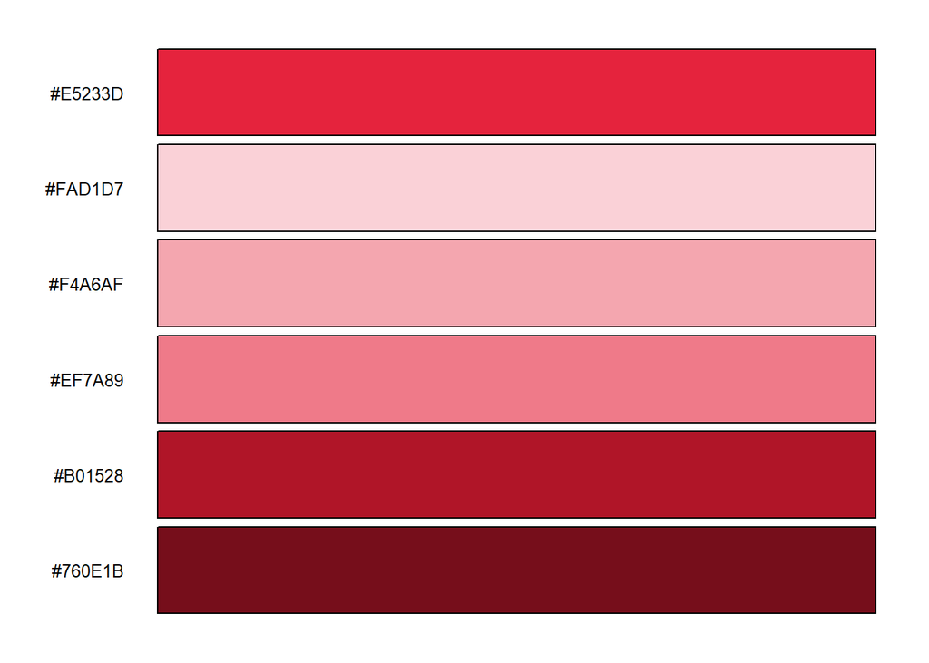

```r
choice <- bss_colors %>% filter(col_pal == 7)
swatch(choice$hashed_hex)
```

### basic colors

The following diagram contains all basic bss colors. They are stored in a vector with the corresponding names. Unlike to the bss_colors table, these colors can therefore be called in functions by their names. When the package is loaded the vector can be called with the `basic_colors` command. However, the basic bss colors can also be found in the bigger above shown bss_colors table, as it includes all colors.

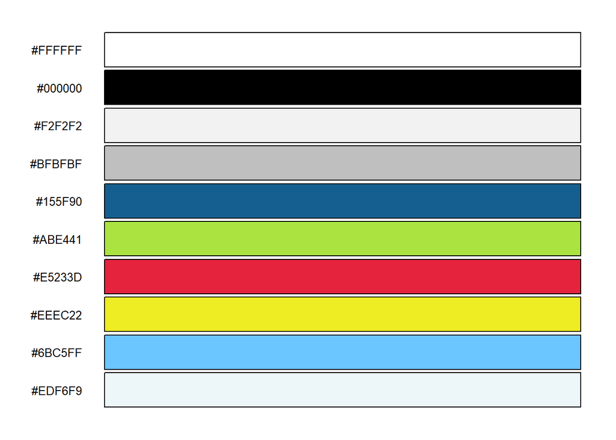

```r
basic_colors
```

```
#>     weiss   schwarz hellgrau1      grau      blau      grün       rot      gelb
#> "#FFFFFF" "#000000" "#F2F2F2" "#BFBFBF" "#155F90" "#ABE441" "#E5233D" "#EEEC22"
#>  hellblau hellgrau2
#> "#6BC5FF" "#EDF6F9"
```

## function: bss_cols() - examples

The bss_cols function allows you to get and reference hex colors in a robust and flexible way for the basic_colors. As you can see in the example below, I am calling the colors by their names. Hence, this function does not work with the hex codes of the big, above showed bss_colors table.

```r
# to get the basic colors
bss_cols()
```

```
#>     weiss   schwarz hellgrau1      grau      blau      grün       rot      gelb
#> "#FFFFFF" "#000000" "#F2F2F2" "#BFBFBF" "#155F90" "#ABE441" "#E5233D" "#EEEC22"
#>  hellblau hellgrau2
#> "#6BC5FF" "#EDF6F9"
```

```r
# to get the information of a color
bss_cols("rot")
```

```
#>       rot
#> "#E5233D"
```

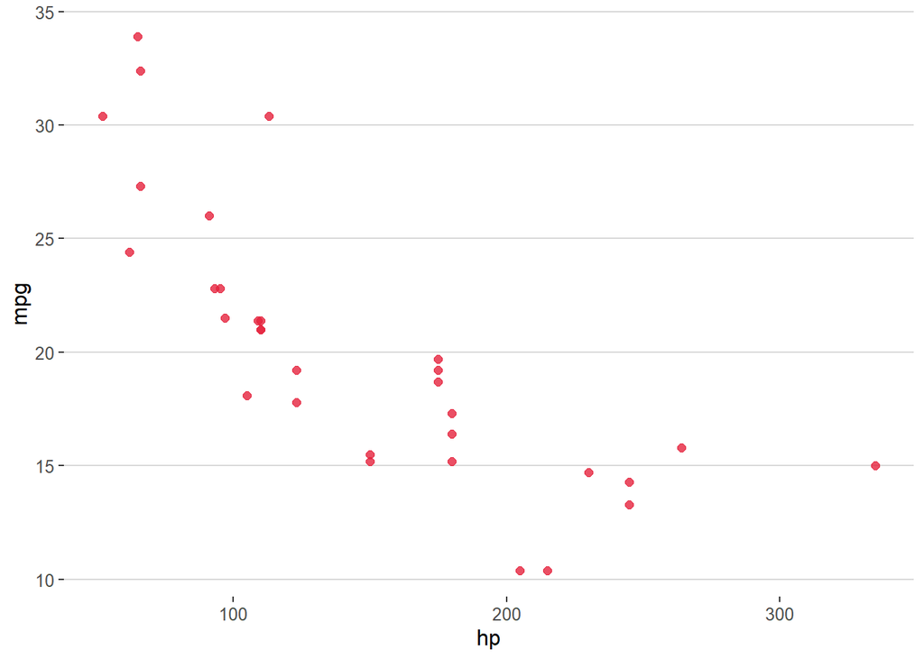

```r
# or to just use a color in a plot
ggplot(mtcars, aes(hp, mpg)) +
  geom_point(color = bss_cols("rot"),
             size = 2, alpha = .8)+
  theme_hc()
```

## function: bss_pal() - examples

With the command `bss_palettes` you can see all the coded palettes stored in a list.

```r
# the following subset color palettes are available
bss_palettes
```

```
#> $monochrome_black1
#>            [,1]      [,2]      [,3]      [,4]      [,5]      [,6]
#> hashed_hex "#808080" "#A6A6A6" "#BFBFBF" "#D9D9D9" "#F2F2F2" "#FFFFFF"
#>
#> $black_yellow
#>  [1] "#808080" "#A6A6A6" "#BFBFBF" "#D9D9D9" "#F2F2F2" "#FFFFFF" "#FCFCD1"
#>  [8] "#F9F9A6" "#F4F479" "#EEEC22" "#BDBD0F" "#7E7E0A"
#>
#> $monochrome_green
#>            [,1]      [,2]      [,3]      [,4]      [,5]      [,6]
#> hashed_hex "#5A8112" "#86BF1C" "#ABE441" "#CCEE8C" "#DDF4B3" "#EEFAD8"
#>
#> $monochrome_red
#>            [,1]      [,2]      [,3]      [,4]      [,5]      [,6]
#> hashed_hex "#760E1B" "#B01528" "#E5233D" "#EF7A89" "#F4A6AF" "#FAD1D7"
#>
#> $red_green
#>  [1] "#760E1B" "#B01528" "#E5233D" "#EF7A89" "#F4A6AF" "#FAD1D7" "#EEFAD8"
#>  [8] "#DDF4B3" "#CCEE8C" "#ABE441" "#86BF1C" "#5A8112"
#>
#> $red_yellow
#>  [1] "#760E1B" "#B01528" "#E5233D" "#EF7A89" "#F4A6AF" "#FAD1D7" "#FCFCD1"
#>  [8] "#F9F9A6" "#F4F479" "#EEEC22" "#BDBD0F" "#7E7E0A"
#>
#> $monochrome_yellow
#>            [,1]      [,2]      [,3]      [,4]      [,5]      [,6]
#> hashed_hex "#7E7E0A" "#BDBD0F" "#EEEC22" "#F4F479" "#F9F9A6" "#FCFCD1"
#>
#> $monochrome_blue
#>            [,1]      [,2]      [,3]      [,4]      [,5]      [,6]
#> hashed_hex "#006CB5" "#0F9FFF" "#6BC5FF" "#A6DBFF" "#C4E8FF" "#E1F3FF"
#>
#> $blue_yellow
#>  [1] "#006CB5" "#0F9FFF" "#6BC5FF" "#A6DBFF" "#C4E8FF" "#E1F3FF" "#FCFCD1"
#>  [8] "#F9F9A6" "#F4F479" "#EEEC22" "#BDBD0F" "#7E7E0A"
#>
#> $blue_green
#>  [1] "#006CB5" "#0F9FFF" "#6BC5FF" "#A6DBFF" "#C4E8FF" "#E1F3FF" "#EEFAD8"
#>  [8] "#DDF4B3" "#CCEE8C" "#ABE441" "#86BF1C" "#5A8112"
#>
#> $blue_red
#>  [1] "#006CB5" "#0F9FFF" "#6BC5FF" "#A6DBFF" "#C4E8FF" "#E1F3FF" "#FAD1D7"
#>  [8] "#F4A6AF" "#EF7A89" "#E5233D" "#B01528" "#760E1B"
#>
#> $main
#>            [,1]      [,2]      [,3]      [,4]      [,5]      [,6]
#> hashed_hex "#FFFFFF" "#000000" "#F2F2F2" "#BFBFBF" "#155F90" "#ABE441"
#>            [,7]      [,8]      [,9]      [,10]
#> hashed_hex "#E5233D" "#EEEC22" "#6BC5FF" "#EDF6F9"
#>
#> $main_only_color
#>            [,1]      [,2]      [,3]      [,4]      [,5]
#> hashed_hex "#155F90" "#ABE441" "#E5233D" "#EEEC22" "#6BC5FF"
```

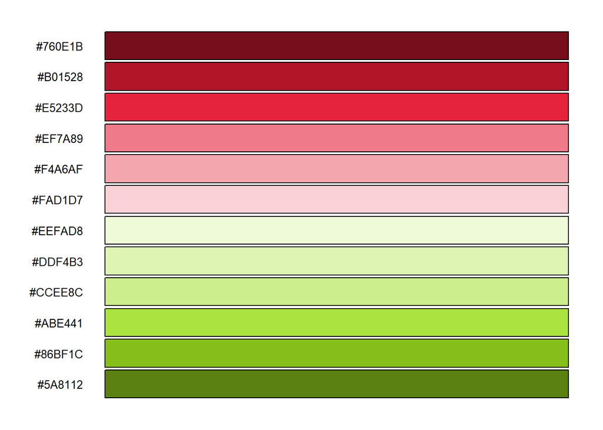

```r
#e.g.
swatch(bss_palettes$red_green)
```

The function `bss_pal()` allows to interpolate the palette colors for a certain number of levels, making it possible to create shades between the original colors using colorRampPalette from grDevices. This command can be used to extend to numbers of colors in a palette, however the hex codes of some color shades can then deviate from the above bss_colors table. Therefore, I recommend to use the coded palettes mentioned above, if possible.

```r
# interpolate the "main_only_color" palette (which only includes five colors) to a length of 20:
bss_pal("main_only_color")(20)
```

```
#>  [1] "#155F90" "#347B7F" "#54976E" "#73B35E" "#93CF4D" "#AED940" "#BAB13F"
#>  [8] "#C6883F" "#D25F3E" "#DE373D" "#E5383A" "#E76234" "#E98C2E" "#EBB729"
#> [15] "#EDE123" "#D9E544" "#BDDD73" "#A2D5A1" "#86CDD0" "#6BC5FF"
```

The function `bss_pal` gets a palette by name from the list above (“main_only_color” by default) and has a boolean condition (`rev =T/F`) determining whether to reverse the order of colors or not.

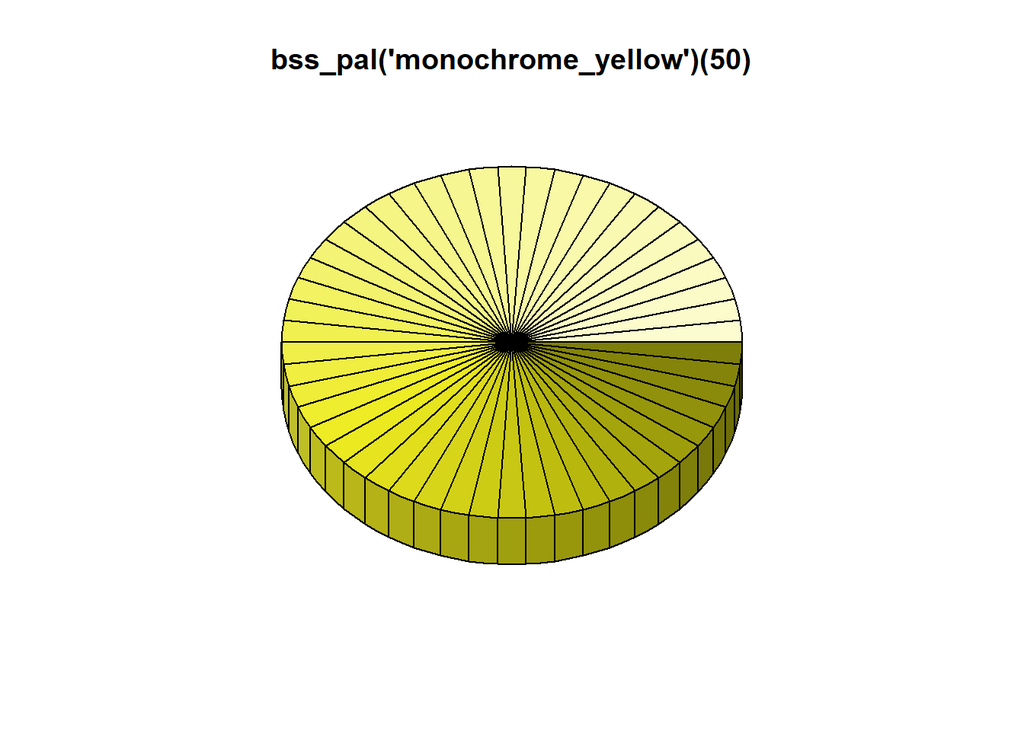

```r
# Example of pie chart extending monochrome_yellow palettes to 50 shades.
pie3D(rep(5, 50),explode=0, theta=1.2, col=bss_pal(rev = T,"monochrome_yellow")(50),main="bss_pal('monochrome_yellow')(50)")
```

## function: scale_color_bss() - example

`scale_color_bss()` is a custom color scale function for ggplot2 plots. The same could also be achieved with the function `scale_colour_manual` of the ggplot2 package. However, the usage of the bsscol palettes makes this process more tidy and efficient. In the function two boolean parameters `discrete = T/F, reverse = T/F` can be choosen.

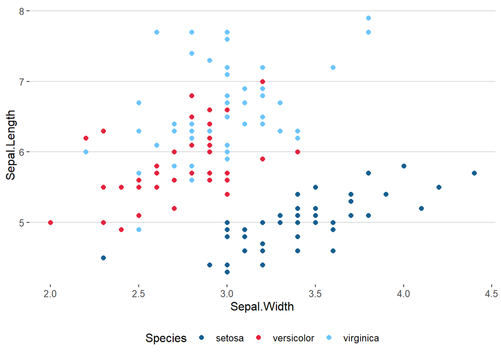

```r
# Color by discrete variable using default palette main_only_color
ggplot(iris, aes(Sepal.Width, Sepal.Length, color = Species)) +
  geom_point(size = 2) +
  scale_color_bss() +
  theme_hc()
```

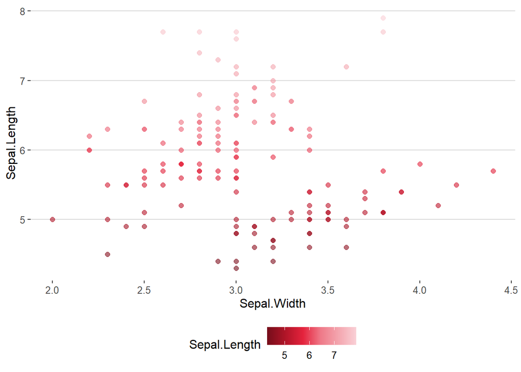

```r
# Color by numeric variable with monochrome_red palette
ggplot(iris, aes(Sepal.Width, Sepal.Length, color = Sepal.Length)) +
  geom_point(size = 2, alpha = .6) +
  scale_color_bss(discrete = FALSE, palette = "monochrome_red")+
  theme_hc()
```

## function: scale_fill_bss() - example

`scale_fill_bss()` is a custom fill scale function for ggplot2 plots. The same could also be achieved with the function `scale_fill_manual` of the ggplot2 package. However, the usage of the bsscol palettes makes this process more tidy and efficient. The shades of colors are automatically extended when using more colors than a standard palettes has to offer. In the function two boolean parameters `discrete = T/F, reverse = T/F` can be chosen.

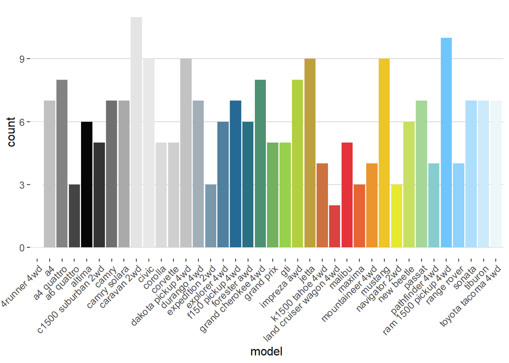

```r
# Fill by discrete variable with the main palette + remove legend (guide)
ggplot(mpg, aes(model          , fill = model         )) +
  geom_bar() +
  theme(axis.text.x = element_text(angle = 45, hjust = 1)) +
  scale_fill_bss(palette = "main", guide = "none")+
  theme_hc()
```